# egg project

The author and I got the same P-Values.

Next i performed a regression describing the relationship between egg mass and eggshell thickness.

#Regression

```r
datadino<-data%>%filter(Clade=="Neognaths"|Clade=="Non-avian_dinosaurs"|Clade=="Paleognaths"|Clade== "Enantiornithes"|Clade=="Ornithuromorphs")
regressL<- lm(Eggshell_thickness~Egg_mass,data = datadino)
summary(regressL)
```

```
##
## Call:
## lm(formula = Eggshell_thickness ~ Egg_mass, data = datadino)
##
## Residuals:
##     Min      1Q  Median      3Q     Max
## -1379.5  -322.4  -182.3   280.5  1535.5
##
## Coefficients:
##              Estimate Std. Error t value Pr(>|t|)
## (Intercept) 474.10192   53.64858   8.837 1.58e-14 ***
## Egg_mass      0.38669    0.02939  13.159  < 2e-16 ***
## ---
## Signif. codes:  0 '***' 0.001 '**' 0.01 '*' 0.05 '.' 0.1 ' ' 1
##
## Residual standard error: 498.2 on 112 degrees of freedom
##   (1 observation deleted due to missingness)
## Multiple R-squared:  0.6072, Adjusted R-squared:  0.6037
## F-statistic: 173.2 on 1 and 112 DF,  p-value: < 2.2e-16
```

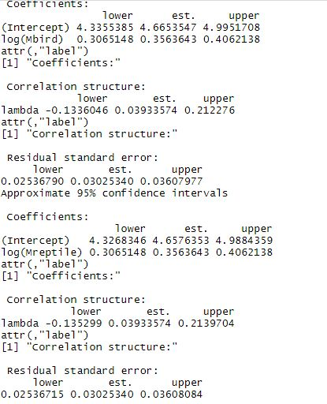

```r
#Authors Regression
knitr::include_graphics("Author reg.JPG")
```

The R- squared value shows a that there is a relationship between but not a high correlation but the the relationship statistically significant

My values and the authors values were not the same

Next i ran regression on egg mass and eggshell thickness to body mass.

```r
regress1<- lm(Egg_mass+Eggshell_thickness~Body_mass,data = data)
summary(regress1)
```

```
##
## Call:
## lm(formula = Egg_mass + Eggshell_thickness ~ Body_mass, data = data)
##
## Residuals:
##    Min     1Q Median     3Q    Max
## -801.5 -136.9  -54.6   45.1  745.7
##
## Coefficients:
##              Estimate Std. Error t value Pr(>|t|)
## (Intercept) 2.541e+02  3.428e+01   7.412 7.97e-10 ***
## Body_mass   3.505e-02  6.421e-04  54.589  < 2e-16 ***
## ---
## Signif. codes:  0 '***' 0.001 '**' 0.01 '*' 0.05 '.' 0.1 ' ' 1
##
## Residual standard error: 249 on 55 degrees of freedom
##   (117 observations deleted due to missingness)
## Multiple R-squared:  0.9819, Adjusted R-squared:  0.9815
## F-statistic:  2980 on 1 and 55 DF,  p-value: < 2.2e-16
```

#Data Visualization  
I used ggplot for this graph that represents Ln of egg mass vs Ln of eggshell thickness. I was under the impression it did not load but it did .

Read in table for equations

```r
EggMass<-read.table ("Data_Eggmass_equations.txt", header=TRUE)
```

Plot egg mass vs eggshell thickness

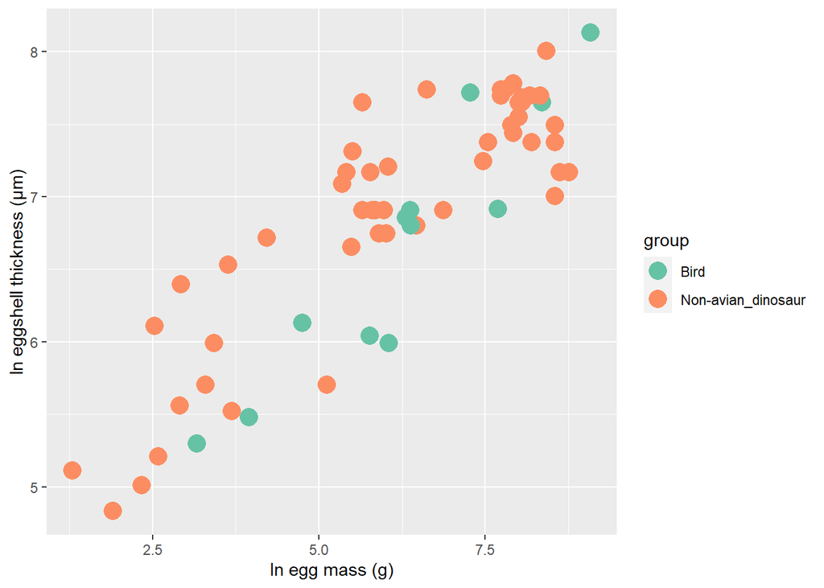

```r
ggplot(EggMass, aes(log(Mreptile), log(Eggshell_thickness), color=Group)) +
geom_point(size=5) +
xlab("ln egg mass (g)") +
ylab("ln eggshell thickness (µm)") +
scale_colour_brewer("group", palette="Set2")
```

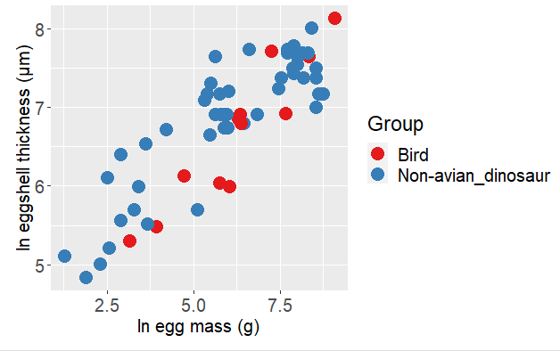

```r
#Authors graph
knitr::include_graphics("pic2.png")
```

Plot body mass vs egg mass

```r
datamass<-subset(data, !is.na(data$Body_mass))
```